# R Notebook

Question 1 As part of their analysis of the Federalist papers, Mosteller and Wallace (1964) recorded the frequency of use of various words in selected articles by Alexander Hamilton and James Madison. The articles were divided into blocks (247 for Hamilton, 262 for Madison) of about 200 words each, and the number of instances of various words in each block were recorded. The table below displays the results for the word “may.” # occurrences in a block 0 1 2 3 4 5 6 7+ Total blocks # blocks (Hamilton) 128 67 32 14 4 1 1 0 247 # blocks (Madison) 156 63 29 8 4 1 1 0 262

These data are also provided in the hamilton and madison vectors. a) Fit a Poisson model to these data, with different parameters for each author and a noninformative/weakly informative prior distirbution. Plot the posterior density of the Poisson mean parameter for each author. Interpret. Fit the model in Stan:

```r
library(rstan)
load("FinalExam.RData")
hamilton
```

```
  [1] 0 0 0 0 0 0 0 0 0 0 0 0 0 0 0 0 0 0 0 0 0 0 0 0 0 0 0 0 0 0 0 0 0 0 0 0 0 0 0 0 0 0 0 0 0 0 0 0 0 0
 [51] 0 0 0 0 0 0 0 0 0 0 0 0 0 0 0 0 0 0 0 0 0 0 0 0 0 0 0 0 0 0 0 0 0 0 0 0 0 0 0 0 0 0 0 0 0 0 0 0 0 0
[101] 0 0 0 0 0 0 0 0 0 0 0 0 0 0 0 0 0 0 0 0 0 0 0 0 0 0 0 0 1 1 1 1 1 1 1 1 1 1 1 1 1 1 1 1 1 1 1 1 1 1
[151] 1 1 1 1 1 1 1 1 1 1 1 1 1 1 1 1 1 1 1 1 1 1 1 1 1 1 1 1 1 1 1 1 1 1 1 1 1 1 1 1 1 1 1 1 1 2 2 2 2 2
[201] 2 2 2 2 2 2 2 2 2 2 2 2 2 2 2 2 2 2 2 2 2 2 2 2 2 2 2 3 3 3 3 3 3 3 3 3 3 3 3 3 3 4 4 4 4 5 6
```

```r
madison
```

```
  [1] 0 0 0 0 0 0 0 0 0 0 0 0 0 0 0 0 0 0 0 0 0 0 0 0 0 0 0 0 0 0 0 0 0 0 0 0 0 0 0 0 0 0 0 0 0 0 0 0 0 0
 [51] 0 0 0 0 0 0 0 0 0 0 0 0 0 0 0 0 0 0 0 0 0 0 0 0 0 0 0 0 0 0 0 0 0 0 0 0 0 0 0 0 0 0 0 0 0 0 0 0 0 0
[101] 0 0 0 0 0 0 0 0 0 0 0 0 0 0 0 0 0 0 0 0 0 0 0 0 0 0 0 0 0 0 0 0 0 0 0 0 0 0 0 0 0 0 0 0 0 0 0 0 0 0
[151] 0 0 0 0 0 0 1 1 1 1 1 1 1 1 1 1 1 1 1 1 1 1 1 1 1 1 1 1 1 1 1 1 1 1 1 1 1 1 1 1 1 1 1 1 1 1 1 1 1 1
[201] 1 1 1 1 1 1 1 1 1 1 1 1 1 1 1 1 1 1 1 2 2 2 2 2 2 2 2 2 2 2 2 2 2 2 2 2 2 2 2 2 2 2 2 2 2 2 2 2 3 3
[251] 3 3 3 3 3 3 4 4 4 4 5 6
```

```r
mean(hamilton)
```

```
[1] 0.8097166
```

```r
mean(madison)
```

```
[1] 0.6564885
```

```r
set.seed(500)
mod1code <- '
data{
  int<lower=0> y[247];
}
parameters{
  real <lower=0> lambda1;
}
model{
  lambda1 ~gamma(0.01,0.01);
  for(i in 1:247){
    y[i] ~ poisson(lambda1);
  }
}
'
mod1dat <- list(y=hamilton)
mod1 <- stan(model_code=mod1code, data=mod1dat)
```

[output not shown]

[output cut: 14 more lines]

[output not shown]

```r
print(mod1,pars="lambda1")
```

```
Inference for Stan model: 2dc97e7f3770ef45527d206bfcf757a0.
4 chains, each with iter=2000; warmup=1000; thin=1;
post-warmup draws per chain=1000, total post-warmup draws=4000.

        mean se_mean   sd 2.5%  25%  50%  75% 97.5% n_eff Rhat
lambda1 0.81       0 0.06  0.7 0.77 0.81 0.85  0.93  3142    1

Samples were drawn using NUTS(diag_e) at Sun Dec 11 16:51:46 2016.
For each parameter, n_eff is a crude measure of effective sample size,
and Rhat is the potential scale reduction factor on split chains (at
convergence, Rhat=1).
```

```r
set.seed(501)
mod2code <- '
data{
  int<lower=0> y[262];
}
parameters{
  real <lower=0> lambda2;
}
model{
  lambda2 ~gamma(0.01,0.01);
  for(i in 1:262){
    y[i] ~ poisson(lambda2);
  }
}
'
mod2dat <- list(y=madison)
mod2 <- stan(model_code=mod2code, data=mod2dat)
```

[output not shown]

[output cut: 17 more lines]

[output not shown]

```r
print(mod2,pars="lambda2")
```

```
Inference for Stan model: 6af5ecfd9319f3c6e80861de77ba94ac.
4 chains, each with iter=2000; warmup=1000; thin=1;
post-warmup draws per chain=1000, total post-warmup draws=4000.

        mean se_mean   sd 2.5%  25%  50%  75% 97.5% n_eff Rhat
lambda2 0.66       0 0.05 0.56 0.62 0.65 0.69  0.76  3051    1

Samples were drawn using NUTS(diag_e) at Sun Dec 11 16:54:20 2016.
For each parameter, n_eff is a crude measure of effective sample size,
and Rhat is the potential scale reduction factor on split chains (at
convergence, Rhat=1).
```

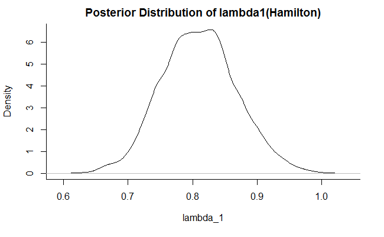

```r
# Plot of posterior distribution of lambda1
lambda1<-extract(mod1)$lambda1
plot(density(lambda1), bty="l",xlab=expression(lambda_1), main="Posterior Distribution of lambda1(Hamilton)")
```

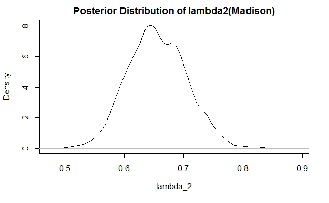

```r
# Plot of posterior distribution of lambda2
lambda2<-extract(mod2)$lambda2
plot(density(lambda2), bty="l",xlab=expression(lambda_2),main="Posterior Distribution of lambda2(Madison)")
```

Thus using noninformative/weakly informative prior distirbution we chose a gamma distribution since we expect $\lambda$ to be positive values greater than 0.We can see for the Hamilton data the posterior distribution of $\lambda$ settles to a mean of 0.81 while the posterior distribution of $\lambda$ settles to a mean of 0.66 for the Madison data. Given the distribution of the data , these values seem reasonable.

There are multiple parameterizations of the negative binomial distribution, but the most convenient for our purpose in Stan is neg_binomial_2; The mean and variance of this distribution are given by EX = $\mu$ and VarX = $\mu$ + $\mu$ $\mu$ /$\phi$ . Here, is called the “dispersion parameter,” and $\delta$= 1/$\phi$

The negative binomial model can be used to address potential overdispersion relative to the Poisson. The negative binomial distribution converges to a possion distribution as $\phi$ to becomes very large . Small values of $\phi$ drag the mode of the distribution towards 0.A reasonable noninformative/weakly informative priors for hamilton are : $\mu$ must be a positive real number from say a gamma distribution. Since the distribution is skewed towards 0, we choose a Gamma(0.01,0.01) and also $\phi$ must also be a positive real number hence we chose phi from a gamma distribution.Let $\phi$ be a Gamma(0.01,0.02). A reasonable noninformative/weakly informative priors for madison are for $\mu$ is Gamma(0.01,0.01) and $\phi$ be a Gamma(0.01,0.01) . ALso note that there is not much dispersion expected since the count of number of occurrences in a block cannot necessarily be heavily overdispersed.

3. Using your priors from part b, fit a negative binomial model to these data, with different parameters for each author. Plot the posterior densities of each parameter. Interpret.

```r
set.seed(503)
mod3code <- '
data{
  int<lower=0> y[247];

}
parameters{
  real <lower=0> mu3;
  real<lower=1>  phi3;
}
model{
  mu3 ~gamma(0.01,0.01);
  phi3 ~ gamma(0.01,0.02);
  for(i in 1:247){
    y[i] ~ neg_binomial_2(mu3,phi3);
  }
}
'
mod3dat <- list(y=hamilton)
mod3 <- stan(model_code=mod3code, data=mod3dat)
```

[output not shown]

[output cut: 39 more lines]

[output not shown]

```r
print(mod3,pars=c("mu3","phi3 "))
```

```
Inference for Stan model: a3a1cd10d84fda2e4442aee730ae801a.
4 chains, each with iter=2000; warmup=1000; thin=1;
post-warmup draws per chain=1000, total post-warmup draws=4000.

     mean se_mean   sd 2.5%  25%  50%  75% 97.5% n_eff Rhat
mu3  0.81    0.00 0.07 0.69 0.76 0.81 0.85  0.95  2568 1.00
phi3 2.13    0.02 1.11 1.11 1.51 1.86 2.40  4.75  2411 1.01

Samples were drawn using NUTS(diag_e) at Sun Dec 11 17:07:45 2016.
For each parameter, n_eff is a crude measure of effective sample size,
and Rhat is the potential scale reduction factor on split chains (at
convergence, Rhat=1).
```

```r
set.seed(504)
mod4code <- '
data{
  int<lower=0> y[262];
}
parameters{
  real <lower=0> mu4;
  real<lower=1>  phi4;
}
model{
  mu4 ~ gamma(0.01,0.01);
  phi4 ~ gamma(0.01,0.01);
  for(i in 1:262){
    y[i] ~ neg_binomial_2(mu4,phi4);
  }
}
'
mod4dat <- list(y=madison)
mod4 <- stan(model_code=mod4code, data=mod4dat)
```

[output not shown]

[output cut: 42 more lines]

[output not shown]

```r
print(mod4,pars=c("mu4","phi4"))
```

```
Inference for Stan model: ffe59bb1b110ba36a1513916665912b9.
4 chains, each with iter=2000; warmup=1000; thin=1;
post-warmup draws per chain=1000, total post-warmup draws=4000.

     mean se_mean   sd 2.5%  25%  50%  75% 97.5% n_eff Rhat
mu4  0.66    0.00 0.06 0.55 0.62 0.65 0.69  0.78  2387    1
phi4 1.49    0.01 0.48 1.02 1.16 1.36 1.66  2.72  2647    1

Samples were drawn using NUTS(diag_e) at Sun Dec 11 17:08:55 2016.
For each parameter, n_eff is a crude measure of effective sample size,
and Rhat is the potential scale reduction factor on split chains (at
convergence, Rhat=1).
```

4. Use posetrior predictive checks to determine which model provides a better fit to our data. #####Poisson Model ##############

```r
# Obtain posterior distribution of lambda for Hamilton
par(mfrow=c(1,2))
lambda1<- extract(mod1)$lambda1
# Construct and plot the posterior predicitve distribution, 95% PI
x.pred.a <- rpois(4000,lambda1)
hist(x.pred.a,breaks=seq(min(x.pred.a)-.5,max(x.pred.a)+.5,1),
col="lightgray",freq=FALSE,xlab=expression(tilde(x)),
main="Poisson Post. Predictive (Hamilton)")
x.pred.a.95 <- quantile(x.pred.a,c(.025,.975))
abline(v=x.pred.a.95+c(-.5,.5),lty=2,lwd=2,col="red")
```

```r
mean(x.pred.a.95)
```

```
[1] 1.5
```

```r
x.pred.a.95
```

```
 2.5% 97.5%
    0     3
```

```r
# Obtain posterior distribution of lambda for Hamilton
mu3<- extract(mod3)$mu3
phi3<-extract(mod3)$phi3
# Construct and plot the posterior predicitve distribution, 95% PI
x.pred.a<-matrix(NA,4000,8)
for(i in 1:8){
x.pred.a[,i] <- rnbinom(4000,size=i,mu=mu3)
}
hist(x.pred.a,breaks=seq(min(x.pred.a)-.5,max(x.pred.a)+.5,1),
col="lightgray",freq=FALSE,xlab=expression(tilde(x)),
main="Neg Binom Post. Predictive (Hamilton)")
x.pred.a.95 <- quantile(x.pred.a,c(.025,.975))
x.pred.a.95
```

```
 2.5% 97.5%
    0     3
```

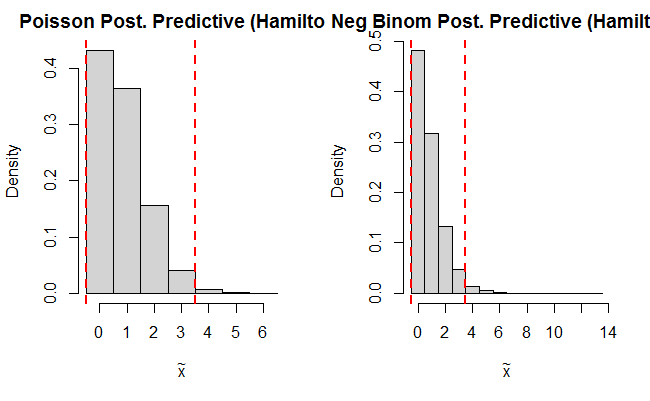

```r
abline(v=x.pred.a.95+c(-.5,.5),lty=2,lwd=2,col="red")
```

```r
mean(x.pred.a.95)
```

```
[1] 1.5
```

```r
# Obtain posterior distribution of lambda for Madison
par(mfrow=c(1,2))
lambda2<- extract(mod2)$lambda2
# Construct and plot the posterior predicitve distribution, 95% PI
x.pred.a <- rpois(4000,lambda2)
hist(x.pred.a,breaks=seq(min(x.pred.a)-.5,max(x.pred.a)+.5,1),
col="lightgray",freq=FALSE,xlab=expression(tilde(x)),
main=" Poisson Posterior Predictive (Madison)")
x.pred.a.95 <- quantile(x.pred.a,c(.025,.975))
abline(v=x.pred.a.95+c(-.5,.5),lty=2,lwd=2,col="red")
```

```r
mean(x.pred.a.95)
```

```
[1] 1.5
```

```r
x.pred.a.95
```

```
 2.5% 97.5%
    0     3
```

```r
# Obtain posterior distribution of lambda for Madison
mu4<- extract(mod4)$mu4
phi4<-extract(mod4)$phi4
# Construct and plot the posterior predicitve distribution, 95% PI
x.pred.a<-matrix(NA,4000,8)
for(i in 1:8){
x.pred.a[,i] <- rnbinom(4000,size=i,mu=mu4)
}
hist(x.pred.a,breaks=seq(min(x.pred.a)-.5,max(x.pred.a)+.5,1),
col="lightgray",freq=FALSE,xlab=expression(tilde(x)),
main="Neg Binom Post. Predictive (Madison)")
x.pred.a.95 <- quantile(x.pred.a,c(.025,.975))
x.pred.a.95
```

```
 2.5% 97.5%
    0     3
```

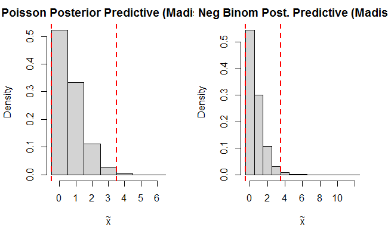

```r
abline(v=x.pred.a.95+c(-.5,.5),lty=2,lwd=2,col="red")
```

Secondly , it at least has a dispersion parameter which tell us some information about the dispersion in the data , which is very useful for future extrapolations and analysis .